# Session 8: Application Programming Interface (APIs)

Introduction to Web Scraping and Data Management for Social Scientists

Johannes B. Gruber

2026-07-29

# Introduction

## This Course

| Day | Session |
| --- | --- |
| 1 | Introduction |
| 2 | Data Structures and Wrangling |
| 3 | Working with Files |
| 4 | Linking and joining data & SQL |
| 5 | Database Software and Scaling your Analyses |
| 6 | Introduction to the Web |
| 7 | Static Web Pages |
| 8 | Application Programming Interface (APIs) |
| 9 | Interactive Web Pages |
| 10 | Building a Reproducible Research Project |

## The Plan for Today

In this session, we learn how to adopt data from someone else. We will:

- Learn what an API is and what parts it consists of
- Learn about `httr2`, a modern intuitive package to communicate with APIs
- Discuss some examples:
  - A simple first API: The Guardian API
  - UK Parliament API
  - Semantic Scholar API
- Go into a bit more detail on requesting raw data

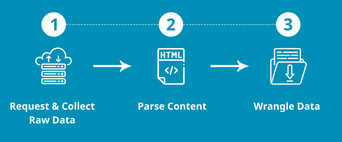

Original Image Source: prowebscraper.com

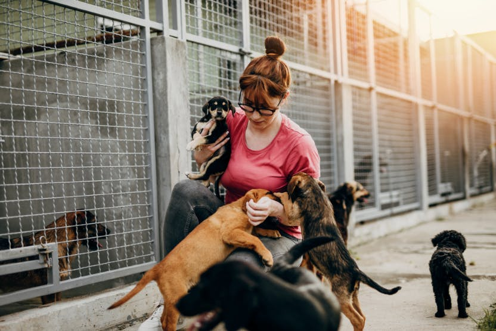

[By Emily Gantt](https://wagwalking.com/daily/a-day-in-the-life-of-an-animal-shelter-volunteer)

# What are APIs?

## What is An Application Programming Interface (API)?

- An Application Programming Interface (API) is a way for two computer programs to speak to each other
- In modern software development they are used extensively when:
  - two programs are not on the same machine
  - two applications are not in the same language
  - when the inner workings of a software should be obscured, but its functionality is offered for customization
  - when a graphic user interface would be inconvenient at scale
- Several important types (SOAP, GraphQL, etc.), but we will focus on REST (Representational state transfer) APIs
- Commonly used to distribute data or do many other things
- A few prominent examples:
  - the Twitter and Facebook APIs (both effectively defunct)
  - the ChatGPT API, which is used to build many additional services
  - news APIs like The Guardian and NYT
  - financial APIs
  - translation APIs (Google, Bing and DeepL)

## Parts of an API call

API calls usually combine several elements:

- a **base URL** of the service (e.g., `https://api.openai.com/`)
- an **endpoint** for a specific service, usually accessed through a sub-directory (e.g., `/v1/completions`)
- an API **method**: `GET`, `POST`, `PUT`, `DELETE`, `PATCH` `QUERY`<sup>1</sup> (only `GET` and sometimes `POST` are important for us )
- **headers** containing some settings, e.g., what format you want to receive the data in (JSON, XML, HTML etc.), and communicating who you are through user-agent, cookies, device and software information that is usually used for debugging
- **query parameters**, i.e., your search term, filters, what fields/columns you want to access, how many results you want to receive, how results are ordered etc (`?q=parliament%20AND%20debate`)
- a **body** if your request contains some more complicated instructions (not for `GET` requests)
- **authentication**, usually in form of a token (a standardized string, similar to a password)
[^1]: Only since June 2026

## Parts of an API response

APIs respond to a call. The response usually also contains several elements:

- a **status code**: 200s mean success, 300s mean success with some caveat, 400+ are request errors (not found, forbidden), 500 is a server error
- **headers** provide additional information about the response (e.g., type of data returned, size of the data, time stamp)
- **body**: the main response containing the requested data (e.g., as JSON or HTML)
- **response metadata**: more information about the response (e.g., pagination information, version numbers, remaining rate limit allowance, link to next page)
- **error messages**: when unsuccessful, the API might include an error message on top of the status code

# Accessing APIs from R

## The `httr2` package

- rewrite of the `httr` which was the de-factor default to develop API packages in `R`
- developed by Hadley Wickham
- tidyverse programming principles
  - telling verbs are used in a pipe
  - requests are build up using `req_*` functions
  - responses are deconstructed using `resp_*`
  - makes wrapping an API in a few functions or a package straightforward

[figure not shown]

# Example: The Guardian API

## Background

- The newspaper `The Guardian` offers all its articles through an open API for free 🤓
- To access the API, you first need to obtain an API key by filling out a small form [here](https://bonobo.capi.gutools.co.uk/register/developer)
- The API key should arrive within seconds per mail
- This is unfortunately very rare in the world of news media ☹️
- To figure out how to use the API, we can use its [documentation](https://open-platform.theguardian.com/documentation/)

Your task: get a key and use `usethis::edit_r_environ(scope = "project")` to open your .Renviron file. Save the API key as the variable `GUARDIAN_KEY`.

## Building Requests

Let’s build our first `httr2` request!

```r
library(httr2)
library(tidyverse, warn.conflicts = FALSE)
req <- request("https://content.guardianapis.com") |> # start the request with the base URL
  req_url_path("search") |> # navigate to the endpoint you want to access
  req_method("GET") |> # specify the method
  req_timeout(seconds = 60) |> # how long to wait for a response
  req_headers("User-Agent" = "httr2 guardian test") |> # specify request headers
  # req_body_json() |>                                 # since this is a GET request the body stays empty
  req_url_query(
    # instead the query is added to the URL
    q = "parliament AND debate",
    "show-blocks" = "all"
  ) |>
  req_url_query(
    # in this case, the API key is also added to the query
    "api-key" = Sys.getenv("GUARDIAN_KEY") # but httr2 also has req_auth_* functions for other
  ) # authentication procedures
print(req)
```

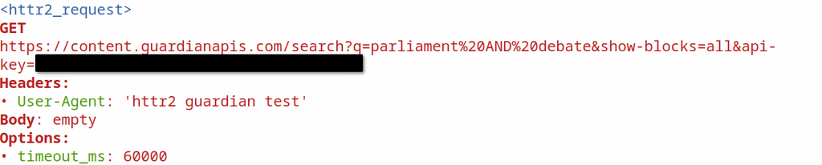

We now built the request. But this doesn’t yet do anything until you also perform it.

## Performing the request

```r
resp <- req_perform(req)
resp
```

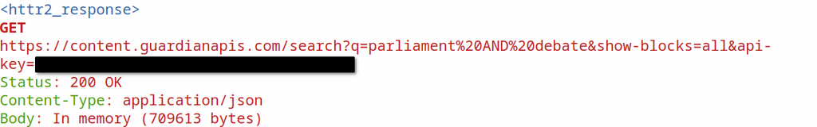

Printing the request tells us several important things:

- the status of the response is OK (hurray!)
- the response carries data in the JSON format
- however, you probably don’t want to manually inspect each response…

## Parsing the response: a first look

We can automatically check if the response has the form we expect:

```r
resp_status(resp) < 400
```

```
[1] TRUE
```

```r
resp_content_type(resp) == "application/json"
```

```
[1] TRUE
```

If we’re happy with the status of the response, we can start to look at the body by transforming it with the correct `resp_body_*` function:

```r
returned_body <- resp_body_json(resp)
lobstr::tree(returned_body, max_length = 25)
```

```
<list>
└─response: <list>
  ├─status: "ok"
  ├─userTier: "developer"
  ├─total: 33393
  ├─startIndex: 1
  ├─pageSize: 10
  ├─currentPage: 1
  ├─pages: 3340
  ├─orderBy: "relevance"
  └─results: <list>
    ├─<list>
    │ ├─id: "politics/2026/apr/16/officials-d..."
    │ ├─type: "article"
    │ ├─sectionId: "politics"
    │ ├─sectionName: "Politics"
    │ ├─webPublicationDate: "2026-04-16T17:39:59Z"
    │ ├─webTitle: "Officials debate withholding Man..."
    │ ├─webUrl: "https://www.theguardian.com/poli..."
    │ ├─apiUrl: "https://content.guardianapis.com..."
    │ ├─blocks: <list>
    │ │ ├─main: <list>
    │ │ │ ├─id: "69e0d9738f08b9e0aac013e2"
    │ │ │ ├─bodyHtml: "<figure class="element element-i..."
    │ │ │ ├─bodyTextSummary: ""
...
```

## Parsing the response: a first look

We already see some useful information about the the result. We could extract that information either with `pluck` from the tidyverse or using square brackets:

```r
pluck(returned_body, "response", "total")
```

```
[1] 33393
```

```r
pluck(returned_body, "response", "pageSize")
```

```
[1] 10
```

```r
pluck(returned_body, "response", "pages")
```

```
[1] 3340
```

```r
returned_body[["response"]][["total"]]
```

```
[1] 33393
```

```r
returned_body[["response"]][["pageSize"]]
```

```
[1] 10
```

```r
returned_body[["response"]][["pages"]]
```

```
[1] 3340
```

## Parsing the response: extracting the data

So far we only got the results for page 1, which is a common way to return results from an API. To get to the other pages that contain results, we would need to loop through all of these pages (by adding the query `page = i`). For now, we can have a closer look at the articles on the first results page.

```r
search_res <- pluck(returned_body, "response", "results")
```

We can have a closer look at this using the Viewer in RStudio:

```r
View(search_res)
```

In typical fashion, this API returns the data in a rather complicated format. This is probably the main reason why people dislike working with APIs in `R`, as it can be very frustrating to get this into a format that makes sense for us.

## Parsing the response: building a data wrangling function

Let’s build a function to select just some important information. We start by writing a few lines of code to parse the first article:

```r
res <- pluck(search_res, 1)
res
```

```
$id
[1] "politics/2026/apr/16/officials-debate-withholding-mandelson-vetting-documents-from-parliament"

$type
[1] "article"

$sectionId
[1] "politics"

$sectionName
[1] "Politics"

$webPublicationDate
[1] "2026-04-16T17:39:59Z"

$webTitle
[1] "Officials debate withholding Mandelson vetting documents from parliament"

$webUrl
[1] "https://www.theguardian.com/politics/2026/apr/16/officials-debate-withholding-mandelson-vetting-documents-from-parliament"

$apiUrl
[1] "https://content.guardianapis.com/politics/2026/apr/16/officials-debate-withholding-mandelson-vetting-documents-from-parliament"

$blocks
$blocks$main
$blocks$main$id
[1] "69e0d9738f08b9e0aac013e2"

$blocks$main$bodyHtml
[1] "<figure class=\"element element-image element--showcase\" data-media-id=\"ec69467fc26d2e96e444f8fe08e98215c3e05b61\"> <img src=\"https://media.guim.co.uk/ec69467fc26d2e96e444f8fe08e98215c3e05b61/0_0_5000_3000/1000.jpg\" alt=\"Peter Mandelson\" width=\"1000\" height=\"600\" class=\"gu-image\" />…

$blocks$main$bodyTextSummary
[1] ""

$blocks$main$attributes
named list()

$blocks$main$published
[1] TRUE
```

[output cut: 270 more lines]

```



$blocks$totalBodyBlocks
[1] 1


$isHosted
[1] FALSE

$pillarId
[1] "pillar/news"

$pillarName
[1] "News"
```

```r
id <- res$id
id
```

```
[1] "politics/2026/apr/16/officials-debate-withholding-mandelson-vetting-documents-from-parliament"
```

```r
type <- res$type
type
```

```
[1] "article"
```

```r
time <- lubridate::ymd_hms(res$webPublicationDate)
time
```

```
[1] "2026-04-16 17:39:59 UTC"
```

```r
headline <- res$webTitle
headline
```

```
[1] "Officials debate withholding Mandelson vetting documents from parliament"
```

## Parsing the response: building a data wrangling function

So far so good, but where is the text? It seems it is stored in these “blocks” -> “body” elements. Let’s have a look:

```r
pluck(res, "blocks", "body")
```

```
[[1]]
[[1]]$id
[1] "69e0b7b18f08fbc58317e1db"

[[1]]$bodyHtml
[1] "<p>Senior government officials have been considering whether to withhold from parliament sensitive documents that show Peter Mandelson <a href=\"https://www.theguardian.com/politics/2026/apr/16/revealed-mandelson-failed-vetting-but-foreign-office-overruled-decision\">failed security vetting</a>…

[[1]]$bodyTextSummary
[1] "Senior government officials have been considering whether to withhold from parliament sensitive documents that show Peter Mandelson failed security vetting before he assumed the role of US ambassador, the Guardian can reveal. Any such decision could amount to an extraordinary breach of a parlia…

[[1]]$attributes
named list()

[[1]]$published
[1] TRUE

[[1]]$createdDate
[1] "2026-04-16T14:06:40Z"

[[1]]$firstPublishedDate
[1] "2026-04-16T14:08:46Z"

[[1]]$publishedDate
[1] "2026-04-17T16:09:34Z"

[[1]]$lastModifiedDate
[1] "2026-04-17T16:09:34Z"

[[1]]$contributors
list()

[[1]]$elements
[[1]]$elements[[1]]
[[1]]$elements[[1]]$type
[1] "text"

[[1]]$elements[[1]]$assets
list()

[[1]]$elements[[1]]$textTypeData
```

[output cut: 99 more lines]

```
[[1]]$elements[[7]]$calloutTypeData$isNonCollapsible
[1] FALSE



[[1]]$elements[[8]]
[[1]]$elements[[8]]$type
[1] "text"

[[1]]$elements[[8]]$assets
list()

[[1]]$elements[[8]]$textTypeData
[[1]]$elements[[8]]$textTypeData$html
[1] "<p>Details of an individual’s UKSV developed vetting results have never before been publicly disclosed, and some top officials have been arguing that doing so would jeopardise national security.</p> \n<p>According to <a href=\"https://www.gov.uk/government/publications/united-kingdom-security-v…
```

## Parsing the response: building a data wrangling function

It seems the API returns articles as HTML strings. Luckily, we know how to extract text from that 😎

```r
library(rvest)
text <- pluck(res, "blocks", "body", 1, "bodyHtml") |>
  read_html() |>
  html_text2()
text
```

```
[1] "Senior government officials have been considering whether to withhold from parliament sensitive documents that show Peter Mandelson failed security vetting before he assumed the role of US ambassador, the Guardian can reveal.\n\nAny such decision could amount to an extraordinary breach of a par…
```

## Parsing the response: finising the data wrangling function

Let’s put this all together:

```r
parse_response <- function(res) {
  text <- pluck(res, "blocks", "body", 1, "bodyHtml") |>
    read_html() |>
    html_text2()

  tibble(
    id = res$id,
    type = res$type,
    time = lubridate::ymd_hms(res$webPublicationDate),
    headline = res$webTitle,
    text = text
  )
}
parse_response(res)
```

```
# A tibble: 1 × 5
  id                                    type  time                headline text
  <chr>                                 <chr> <dttm>              <chr>    <chr>
1 politics/2026/apr/16/officials-debat… arti… 2026-04-16 17:39:59 Officia… "Sen…
```

We can loop over all articles returned by the API and apply this function to it:

```r
map(search_res, parse_response) |>
  bind_rows() # combine the list into one data.frame
```

```
# A tibble: 10 × 5
   id                                   type  time                headline text
   <chr>                                <chr> <dttm>              <chr>    <chr>
 1 politics/2026/apr/16/officials-deba… arti… 2026-04-16 17:39:59 "Offici… "Sen…
 2 news/2026/may/21/jamaica-parliament… arti… 2026-05-21 12:38:35 "‘It’s … "Whe…
 3 society/2026/may/04/parliament-must… arti… 2026-05-04 15:56:51 "Parlia… "The…
 4 uk-news/2026/mar/03/parliament-suic… arti… 2026-03-03 21:05:52 "UK par… "Par…
 5 world/2026/jul/22/india-cockroach-j… arti… 2026-07-22 10:04:40 "Opposi… "Ind…
 6 society/2026/mar/17/scottish-parlia… arti… 2026-03-17 22:44:37 "Scotti… "The…
 7 politics/2026/apr/22/robbins-says-o… arti… 2026-04-22 05:00:09 "Robbin… "Oll…
 8 politics/2026/jul/08/andy-burnham-l… arti… 2026-07-08 21:44:43 "Burnha… "And…
 9 politics/live/2026/apr/24/keir-star… live… 2026-04-24 15:11:33 "Assist… "Tha…
10 australia-news/live/2026/mar/10/ira… live… 2026-03-10 07:42:20 "Fuel s… "Tha…
```

## Exercises 1

First, review the material and make sure you have a broad understanding how to:

- build a request to an API
- perform the request
- handle the response
1. `httr2` has several more functions to customize how a request is performed. What do these functions do?
- `req_throttle`:
- `req_error`:
- `req_retry`:
2. Make your own request to the API with a different search term
3. You might want to add more information to the data.frame. Adapt the function parse_response to also extract: apiUrl, lastModifiedDate, pillarId
4. Request page 2 from the API. You can search for the correct query parameter in the documentation here: https://open-platform.theguardian.com/documentation/

# Example: The UK Parliament API

## Background

- The UK parliament offers several APIs
- You can get data on members, constituencies votes etc.
- The documentation is generated from OpenAPI specifications and rendered with swagger, which is quite convenient

[figure not shown]

## Exploring the Docs

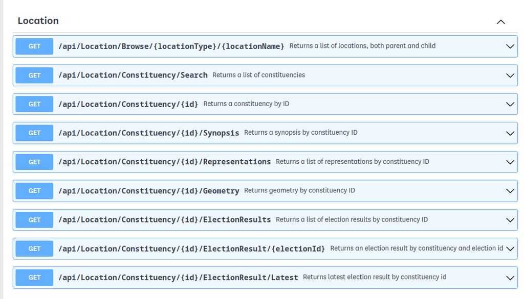

We can look for an endpoint that interests us and even run an example right here!

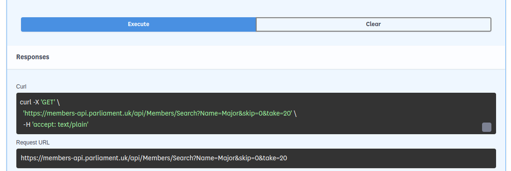

/api/Members/Search endpoint

We even get a Curl call, which makes this really convenient!

## Note: what are `cURL` calls

- `cURL` is a library that can make HTTP requests
- think of it as a general non-R-specific `httr2`
- it is widely used for API calls from the terminal.
- it lists the parameters of a call in a pretty readable manner:
  - the unnamed argument in the beginning is the Uniform Resource Locator (URL) the request goes to
  - `-H` arguments describe the headers, which are arguments sent with the call
  - `-d` is the data or body of a request, which is used e.g., for uploading things
  - `--compressed` means to ask for a compressed response which is unpacked locally (saves bandwidth)

```bash
curl 'https://www.researchgate.net/profile/Johannes-Gruber-2' \
  -H 'accept-language: en-GB,en;q=0.9' \
  -H 'cache-control: max-age=0' \
  -H 'Cookie: [Redacted]' \
  -H 'user-agent: Mozilla/5.0 (X11; Linux x86_64) AppleWebKit/537.36 (KHTML, like Gecko) Chrome/115.0.0.0 Safari/537.36' \
  --compressed
```

A more advanced curl call

## Translating the example request

What’s great about curl calls is that `httr2` has a way to translate them into `R` code:

```r
curl_translate(
  "curl -X 'GET' \
  'https://members-api.parliament.uk/api/Members/Search?Name=Major&skip=0&take=20' \
  -H 'accept: text/plain'"
)
```

```
request("https://members-api.parliament.uk/api/Members/Search") |>
  req_method("GET") |>
  req_url_query(
    Name = "Major",
    skip = "0",
    take = "20",
  ) |>
  req_headers(
    accept = "text/plain",
  ) |>
  req_perform()
```

Some pointers:

- make sure to escape `"` when translating curl calls. You can use the search and replace tool in RStudio and turn `"` inside the curl string into `\"`
- when you call just `curl_translate()`, it uses what is currently in your clipboard, parses it, and copies the result back to your clipboard
- alternatively, use https://curlconverter.com/r-httr2/

## Making the first request from `R`

We can copy the output from `curl_translate()` and run it in `R`. I also added the `resp_body_json()` since we already know the returned data will be json.

```r
search <- request("https://members-api.parliament.uk/api/Members/Search") |>
  req_method("GET") |>
  req_url_query(
    Name = "Major",
    skip = "0",
    take = "20",
  ) |>
  req_headers(
    accept = "text/plain",
  ) |>
  req_perform() |>
  resp_body_json() # <- I added this line to process the response
```

```r
pluck(search, "totalResults")
```

```
[1] 1
```

```r
pluck(search, "items", 1) |>
  lobstr::tree(max_length = 25)
```

```
<list>
├─value: <list>
│ ├─id: 119
│ ├─nameListAs: "Major, Mr John"
│ ├─nameDisplayAs: "Mr John Major"
│ ├─nameFullTitle: "Rt Hon John Major"
│ ├─nameAddressAs: "Mr Major"
│ ├─latestParty: <list>
│ │ ├─id: 4
│ │ ├─name: "Conservative"
│ │ ├─abbreviation: "Con"
│ │ ├─backgroundColour: "0063ba"
│ │ ├─foregroundColour: "ffffff"
│ │ ├─isLordsMainParty: TRUE
│ │ ├─isLordsSpiritualParty: FALSE
│ │ ├─governmentType: 3
│ │ └─isIndependentParty: FALSE
│ ├─gender: "M"
│ ├─latestHouseMembership: <list>
│ │ ├─membershipFrom: "Huntingdon"
│ │ ├─membershipFromId: 1530
│ │ ├─house: 1
│ │ ├─membershipStartDate: "1979-05-03T00:00:00"
│ │ ├─membershipEndDate: "2001-06-07T00:00:00"
│ │ ├─membershipEndReason: "Dissolution"
...
```

## Wrangling the data

As usual, we get some meta information like `totalResults` and the data in a list. To make the `items` more useful, we can bring them into a tabular format.

```r
items <- pluck(search, "items")
tibble(
  id = map_int(items, function(i) pluck(i, "value", "id")),
  nameListAs = map_chr(items, function(i) pluck(i, "value", "nameListAs")),
  nameDisplayAs = map_chr(items, function(i) {
    pluck(i, "value", "nameDisplayAs")
  }),
  nameFullTitle = map_chr(items, function(i) {
    pluck(i, "value", "nameFullTitle")
  }),
  nameAddressAs = map_chr(items, function(i) {
    pluck(i, "value", "nameAddressAs")
  }),
  gender = map_chr(items, function(i) pluck(i, "value", "gender")),
  latestParty = map(items, function(i) pluck(i, "value", "latestParty")),
  latestHouseMembership = map(items, function(i) {
    pluck(i, "value", "latestHouseMembership")
  }),
  test = map_chr(items, function(i) pluck(i, "value", "test", .default = NA))
)
```

```
# A tibble: 1 × 9
     id nameListAs nameDisplayAs nameFullTitle nameAddressAs gender latestParty
  <int> <chr>      <chr>         <chr>         <chr>         <chr>  <list>
1   119 Major, Mr… Mr John Major Rt Hon John … Mr Major      M      <named list>
# ℹ 2 more variables: latestHouseMembership <list>, test <chr>
```

This code is relatively busy, so let’s deconstruct it a little:

- `tibble` wraps the results in a tibble
- `items` is a list, to extract the first element from it, we used `pluck(search, "items", 1)`, but usually we have more than 1 result, so we need to loop over the results using a `map_*` function
- We know what types to expect from our first request, so we choose `map_int` for integer fields, `map_chr` for character fields and `map` for lists

## Wrangling the data

As usual, we get some meta information like `totalResults` and the data in a list. To make the `items` more useful, we can bring them into a tabular format.

```r
items <- pluck(search, "items")
tibble(
  id = map_int(items, function(i) pluck(i, "value", "id")),
  nameListAs = map_chr(items, function(i) pluck(i, "value", "nameListAs")),
  nameDisplayAs = map_chr(items, function(i) {
    pluck(i, "value", "nameDisplayAs")
  }),
  nameFullTitle = map_chr(items, function(i) {
    pluck(i, "value", "nameFullTitle")
  }),
  nameAddressAs = map_chr(items, function(i) {
    pluck(i, "value", "nameAddressAs")
  }),
  gender = map_chr(items, function(i) pluck(i, "value", "gender")),
  latestParty = map(items, function(i) pluck(i, "value", "latestParty")),
  latestHouseMembership = map(items, function(i) {
    pluck(i, "value", "latestHouseMembership")
  }),
  test = map_chr(items, function(i) pluck(i, "value", "test", .default = NA))
)
```

```
# A tibble: 1 × 9
     id nameListAs nameDisplayAs nameFullTitle nameAddressAs gender latestParty
  <int> <chr>      <chr>         <chr>         <chr>         <chr>  <list>
1   119 Major, Mr… Mr John Major Rt Hon John … Mr Major      M      <named list>
# ℹ 2 more variables: latestHouseMembership <list>, test <chr>
```

This code is relatively busy, so let’s deconstruct it a little:

- I included the test column simply to show why we use `pluck` here instead of e.g., `i[["value"]][["id"]]`: we can set a default value if nothing is found
  - many APIs are inconsistent in what they return
  - if you try to extract a field deep in a list with `[[]]`, you will get an error that the field does not exist or `NULL` (which causes an error with `tibble()`)
  - returning `NA` instead makes the parsing safer and is good practice

## Wrapping the endpoint in a function

The reason why APIs are useful is because you can request all kinds of information using a few parameters. This lends itself very well to wrapping specific calls in functions.

```r
# make a new function with different default
safe_pluck <- function(...) {
  pluck(..., .default = NA)
}

search_members <- function(name) {
  # request
  resp <- request("https://members-api.parliament.uk/api/Members/Search") |>
    req_method("GET") |>
    req_url_query(
      Name = name
    ) |>
    req_headers(
      accept = "text/plain",
    ) |>
    req_perform() |>
    resp_body_json()

  # wrangle
  items <- pluck(resp, "items")
  return(tibble(
    id = map_int(items, function(i) safe_pluck(i, "value", "id")),
    nameListAs = map_chr(items, function(i) {
      safe_pluck(i, "value", "nameListAs")
    }),
    nameDisplayAs = map_chr(items, function(i) {
      safe_pluck(i, "value", "nameDisplayAs")
    }),
    nameFullTitle = map_chr(items, function(i) {
      safe_pluck(i, "value", "nameFullTitle")
    }),
    nameAddressAs = map_chr(items, function(i) {
      safe_pluck(i, "value", "nameAddressAs")
    }),
    gender = map_chr(items, function(i) safe_pluck(i, "value", "gender")),
    latestParty = map(items, function(i) safe_pluck(i, "value", "latestParty")),
    latestHouseMembership = map(items, function(i) {
      safe_pluck(i, "value", "latestHouseMembership")
    })
  ))
}
```

## Next Step: testing our function

```r
search_members("Blair")
```

```
# A tibble: 4 × 8
     id nameListAs nameDisplayAs nameFullTitle nameAddressAs gender latestParty
  <int> <chr>      <chr>         <chr>         <chr>         <chr>  <list>
1   512 Blair, Mr… Mr Tony Blair Rt Hon Tony … Mr Blair      M      <named list>
2  4182 Blair of … Lord Blair o… The Lord Bla… The Lord Bla… M      <named list>
3  4377 Donaldson… Stuart Blair… Stuart Blair… Stuart Blair… M      <named list>
4  5076 McDougall… Blair McDoug… Blair McDoug… <NA>          M      <named list>
# ℹ 1 more variable: latestHouseMembership <list>
```

```r
search_members("Smith")
```

```
# A tibble: 20 × 8
      id nameListAs             nameDisplayAs nameFullTitle nameAddressAs gender
   <int> <chr>                  <chr>         <chr>         <chr>         <chr>
 1  5368 Booth-Smith, L.        Lord Booth-S… The Lord Boo… <NA>          M
 2   727 Buchanan-Smith, Alick  Alick Buchan… Rt Hon Alick… <NA>          M
 3  4756 Clarke-Smith, Brendan  Brendan Clar… Brendan Clar… <NA>          M
 4  2723 Delacourt-Smith of Al… Baroness Del… The Baroness… <NA>          F
 5  2713 Dixon-Smith, L.        Lord Dixon-S… The Lord Dix… The Lord Dix… M
 6   152 Duncan Smith, Sir Iain Sir Iain Dun… Rt Hon Sir I… Sir Iain Dun… M
 7  2490 Goldsmith, L.          Lord Goldsmi… The Rt Hon. … <NA>          M
 8  4062 Goldsmith of Richmond… Lord Goldsmi… The Rt Hon. … <NA>          M
 9    29 Johnson Smith, Sir Ge… Sir Geoffrey… Sir Geoffrey… <NA>          M
10  5341 Kyrke-Smith, Laura     Laura Kyrke-… Laura Kyrke-… <NA>          F
11  4554 McGregor-Smith, B.     Baroness McG… The Baroness… <NA>          F
12  5273 Naismith, Connor       Connor Naism… Connor Naism… <NA>          M
13   216 Naysmith, Dr Doug      Dr Doug Nays… Dr Doug Nays… Dr Naysmith   M
14  4738 Smith, Alyn            Alyn Smith    Alyn Smith    <NA>          M
15    95 Smith, Mr Andrew       Mr Andrew Sm… Rt Hon Andre… Mr Smith      M
16  1564 Smith, Angela          Angela Smith  Angela Smith  Angela Smith  F
17    30 Smith, Angela E.       Angela E. Sm… Rt Hon Angel… <NA>          F
18  4436 Smith, Cat             Cat Smith     Cat Smith MP  Cat Smith     F
19  1609 Smith, Chloe           Chloe Smith   Rt Hon Chloe… Chloe Smith   F
20  1292 Smith, Sir Cyril       Sir Cyril Sm… Sir Cyril Sm… <NA>          M
# ℹ 2 more variables: latestParty <list>, latestHouseMembership <list>
```

The Smith search is a little odd since there are surely more than 20 results for this common name.

## Wrapping the endpoint in a function: add pagination

- Most APIs use pagination when the data matching a query becomes too big
- In that case you need to iterate through the pages to get everything
- The UK parliament APIs handles pagination through two parameters:
  - skip: The number of records to skip from the first, default is 0
  - take: The number of records to return, default is 20. Maximum is 20

So to get the second page with the next 20 results, we need to adapt the call:

```r
resp <- request("https://members-api.parliament.uk/api/Members/Search") |>
  req_method("GET") |>
  req_url_query(
    Name = "Smith",
    take = 20,
    skip = 20
  ) |>
  req_headers(
    accept = "text/plain",
  ) |>
  req_perform() |>
  resp_body_json()

# wrangle
items <- pluck(resp, "items")
tibble(
  id = map_int(items, function(i) safe_pluck(i, "value", "id")),
  nameListAs = map_chr(items, function(i) safe_pluck(i, "value", "nameListAs")),
  nameDisplayAs = map_chr(items, function(i) {
    safe_pluck(i, "value", "nameDisplayAs")
  }),
  nameFullTitle = map_chr(items, function(i) {
    safe_pluck(i, "value", "nameFullTitle")
  }),
  nameAddressAs = map_chr(items, function(i) {
    safe_pluck(i, "value", "nameAddressAs")
  }),
  gender = map_chr(items, function(i) safe_pluck(i, "value", "gender")),
  latestParty = map(items, function(i) safe_pluck(i, "value", "latestParty")),
  latestHouseMembership = map(items, function(i) {
    safe_pluck(i, "value", "latestHouseMembership")
  })
)
```

```
# A tibble: 20 × 8
      id nameListAs        nameDisplayAs    nameFullTitle   nameAddressAs gender
   <int> <chr>             <chr>            <chr>           <chr>         <chr>
 1  5218 Smith, David      David Smith      David Smith MP  <NA>          M
 2  1267 Smith, Sir Dudley Sir Dudley Smith Sir Dudley Smi… <NA>          M
 3  4609 Smith, Eleanor    Eleanor Smith    Eleanor Smith   Eleanor Smith F
 4   471 Smith, Geraldine  Geraldine Smith  Geraldine Smith <NA>          F
 5  4778 Smith, Greg       Greg Smith       Greg Smith MP   <NA>          M
 6  3960 Smith, Henry      Henry Smith      Henry Smith     Henry Smith   M
 7  4456 Smith, Jeff       Jeff Smith       Jeff Smith MP   Jeff Smith    M
 8   681 Smith, John       John Smith       John Smith      John Smith    M
 9   564 Smith, Mr John    Mr John Smith    Rt Hon John Sm… <NA>          M
10  4118 Smith, Sir Julian Sir Julian Smith Rt Hon Sir Jul… <NA>          M
11  2852 Smith, L.         The Lord Smith   The Rt Hon. th… <NA>          M
12  4648 Smith, Laura      Laura Smith      Laura Smith     Laura Smith   F
13   541 Smith, Llew       Llew Smith       Llew Smith      <NA>          M
14  3928 Smith, Nick       Nick Smith       Nick Smith MP   Nick Smith    M
15  4042 Smith, Owen       Owen Smith       Owen Smith      Owen Smith    M
16  5301 Smith, Rebecca    Rebecca Smith    Rebecca Smith … <NA>          F
17   639 Smith, Sir Robert Sir Robert Smith Sir Robert Smi… Sir Robert    M
18  4478 Smith, Royston    Royston Smith    Royston Smith   Royston Smith M
19  5117 Smith, Sarah      Sarah Smith      Sarah Smith MP  <NA>          F
20  1245 Smith, Timothy    Timothy Smith    Timothy Smith   <NA>          M
# ℹ 2 more variables: latestParty <list>, latestHouseMembership <list>
```

## Wrapping the endpoint in a function: add pagination

Based on this we can adapt the function

```r
search_members <- function(name) {
  # make the initial request
  resp <- request("https://members-api.parliament.uk/api/Members/Search") |>
    req_method("GET") |>
    req_url_query(
      Name = name,
      take = 20,
      skip = 0
    ) |>
    req_headers(
      accept = "text/plain",
    ) |>
    req_perform() |>
    resp_body_json()

  # checking the total and setting things up for pagination
  total <- resp$totalResults
  message(total, " results found")
  skip <- 0
  page <- 1

  # extract initial results
  items <- pluck(resp, "items")

  # while loops are repeated until the condition inside is FALSE
  while (total > skip) {
    skip <- skip + 20
    page <- page + 1

    # we print a little status message to let the user know work is ongoing
    message("\t...fetching page ", page)

    # we retrieve the next page by adding an increasing skip
    resp <- request("https://members-api.parliament.uk/api/Members/Search") |>
      req_method("GET") |>
      req_url_query(
        Name = name,
        skip = skip,
        take = 20
      ) |>
      req_headers(
        accept = "text/plain",
      ) |>
      req_throttle(rate = 1) |> # do not make more than one request per second
      req_perform() |>
      resp_body_json()

    # we append the original result with the new items
    items <- c(items, pluck(resp, "items"))
  }

  # wrangle
  return(tibble(
    id = map_int(items, function(i) safe_pluck(i, "value", "id")),
    nameListAs = map_chr(items, function(i) {
      safe_pluck(i, "value", "nameListAs")
    }),
    nameDisplayAs = map_chr(items, function(i) {
      safe_pluck(i, "value", "nameDisplayAs")
    }),
    nameFullTitle = map_chr(items, function(i) {
      safe_pluck(i, "value", "nameFullTitle")
    }),
    nameAddressAs = map_chr(items, function(i) {
      safe_pluck(i, "value", "nameAddressAs")
    }),
    gender = map_chr(items, function(i) safe_pluck(i, "value", "gender")),
    latestParty = map(items, function(i) safe_pluck(i, "value", "latestParty")),
    latestHouseMembership = map(items, function(i) {
      safe_pluck(i, "value", "latestHouseMembership")
    })
  ))
}
```

```r
search_members("Smith")
```

```
# A tibble: 52 × 8
      id nameListAs             nameDisplayAs nameFullTitle nameAddressAs gender
   <int> <chr>                  <chr>         <chr>         <chr>         <chr>
 1  5368 Booth-Smith, L.        Lord Booth-S… The Lord Boo… <NA>          M
 2   727 Buchanan-Smith, Alick  Alick Buchan… Rt Hon Alick… <NA>          M
 3  4756 Clarke-Smith, Brendan  Brendan Clar… Brendan Clar… <NA>          M
 4  2723 Delacourt-Smith of Al… Baroness Del… The Baroness… <NA>          F
 5  2713 Dixon-Smith, L.        Lord Dixon-S… The Lord Dix… The Lord Dix… M
 6   152 Duncan Smith, Sir Iain Sir Iain Dun… Rt Hon Sir I… Sir Iain Dun… M
 7  2490 Goldsmith, L.          Lord Goldsmi… The Rt Hon. … <NA>          M
 8  4062 Goldsmith of Richmond… Lord Goldsmi… The Rt Hon. … <NA>          M
 9    29 Johnson Smith, Sir Ge… Sir Geoffrey… Sir Geoffrey… <NA>          M
10  5341 Kyrke-Smith, Laura     Laura Kyrke-… Laura Kyrke-… <NA>          F
# ℹ 42 more rows
# ℹ 2 more variables: latestParty <list>, latestHouseMembership <list>
```

## Adding more parameters

- The [documentation](https://members-api.parliament.uk/index.html) lists a whole lot of other parameters.
- We can copy them into the function to employ them when calling the API.
- We can set the defaults to `NULL`, which means they are ignored by `req_url_query` when not used
- Documentations usually list the required parameters, for which you shouldn’t set a default

```r
search_members <- function(
  name = NULL,
  location = NULL,
  posttitle = NULL,
  partyid = NULL,
  house = NULL,
  constituencyid = NULL,
  namestartswith = NULL,
  gender = NULL,
  membershipstartedsince = NULL,
  membershipended_membershipendedsince = NULL,
  membershipended_membershipendreasonids = NULL,
  membershipindaterange_wasmemberonorafter = NULL,
  membershipindaterange_wasmemberonorbefore = NULL,
  membershipindaterange_wasmemberofhouse = NULL,
  iseligible = NULL,
  iscurrentmember = NULL,
  policyinterestid = NULL,
  experience = NULL
) {
  # 1. request
  resp <- request("https://members-api.parliament.uk/api/Members/Search") |>
    req_method("GET") |>
    req_url_query(
      Name = name,
      Location = location,
      PostTitle = posttitle,
      PartyId = partyid,
      House = house,
      ConstituencyId = constituencyid,
      NameStartsWith = namestartswith,
      Gender = gender,
      MembershipStartedSince = membershipstartedsince,
      MembershipEnded.MembershipEndedSince = membershipended_membershipendedsince,
      MembershipEnded.MembershipEndReasonIds = membershipended_membershipendreasonids,
      MembershipInDateRange.WasMemberOnOrAfter = membershipindaterange_wasmemberonorafter,
      MembershipInDateRange.WasMemberOnOrBefore = membershipindaterange_wasmemberonorbefore,
      MembershipInDateRange.WasMemberOfHouse = membershipindaterange_wasmemberofhouse,
      IsEligible = iseligible,
      IsCurrentMember = iscurrentmember,
      PolicyInterestId = policyinterestid,
      Experience = experience,
      take = 20
    ) |>
    req_headers(
      accept = "text/plain",
    ) |>
    req_perform() |>
    # 2. Parse
    resp_body_json()

  # checking the total and setting things up for pagination
  total <- resp$totalResults
  message(total, " results found")
  skip <- 20
  page <- 1

  # extract initial results
  items <- pluck(resp, "items")

  # while loops are repeated until the condition inside is FALSE
  while (total > skip) {
    page <- page + 1

    # we print a little status message to let the user know work is ongoing
    message("\t...fetching page ", page)

    # we retrieve the next page by adding an increasing skip
    resp <- request("https://members-api.parliament.uk/api/Members/Search") |>
      req_method("GET") |>
      req_url_query(
        Name = name,
        Location = location,
        PostTitle = posttitle,
        PartyId = partyid,
        House = house,
        ConstituencyId = constituencyid,
        NameStartsWith = namestartswith,
        Gender = gender,
        MembershipStartedSince = membershipstartedsince,
        MembershipEnded.MembershipEndedSince = membershipended_membershipendedsince,
        MembershipEnded.MembershipEndReasonIds = membershipended_membershipendreasonids,
        MembershipInDateRange.WasMemberOnOrAfter = membershipindaterange_wasmemberonorafter,
        MembershipInDateRange.WasMemberOnOrBefore = membershipindaterange_wasmemberonorbefore,
        MembershipInDateRange.WasMemberOfHouse = membershipindaterange_wasmemberofhouse,
        IsEligible = iseligible,
        IsCurrentMember = iscurrentmember,
        PolicyInterestId = policyinterestid,
        Experience = experience,
        take = 20,
        skip = skip
      ) |>
      req_headers(
        accept = "text/plain",
      ) |>
      req_perform() |>
      # 2. Parse
      resp_body_json()

    # we append the original result with the new items
    items <- c(items, pluck(resp, "items"))

    # increase the skip number
    skip <- skip + 20
  }

  # wrangle
  return(tibble(
    id = map_int(items, function(i) safe_pluck(i, "value", "id")),
    nameListAs = map_chr(items, function(i) {
      safe_pluck(i, "value", "nameListAs")
    }),
    nameDisplayAs = map_chr(items, function(i) {
      safe_pluck(i, "value", "nameDisplayAs")
    }),
    nameFullTitle = map_chr(items, function(i) {
      safe_pluck(i, "value", "nameFullTitle")
    }),
    nameAddressAs = map_chr(items, function(i) {
      safe_pluck(i, "value", "nameAddressAs")
    }),
    gender = map_chr(items, function(i) safe_pluck(i, "value", "gender")),
    latestParty = map(items, function(i) safe_pluck(i, "value", "latestParty")),
    latestHouseMembership = map(items, function(i) {
      safe_pluck(i, "value", "latestHouseMembership")
    })
  ))
}
```

```r
search_members(
  "Smith",
  partyid = 4,
  house = 1,
  gender = "M",
  iscurrentmember = TRUE
)
```

```
# A tibble: 3 × 8
     id nameListAs nameDisplayAs nameFullTitle nameAddressAs gender latestParty
  <int> <chr>      <chr>         <chr>         <chr>         <chr>  <list>
1   152 Duncan Sm… Sir Iain Dun… Rt Hon Sir I… Sir Iain Dun… M      <named list>
2  4778 Smith, Gr… Greg Smith    Greg Smith MP <NA>          M      <named list>
3  4118 Smith, Si… Sir Julian S… Rt Hon Sir J… <NA>          M      <named list>
# ℹ 1 more variable: latestHouseMembership <list>
```

## Adding documentation

In its current form, the function is working well, but to find out what the parameters do, you would have to visit the documentation website, which isn’t great. To make this more useful, we should add some documentation. In `R`, the `roxygen2` package handles parsing documentation for packages We can use it here to add explanations to the parameters. You can easily add roxygen code to a function using the Code menu in RStudio and Insert Roxygen Skeleton:

```r
#' Search for members of the UK Parliament
#'
#' @param name Members where name contains term specified
#' @param location Members where postcode or geographical location matches the term specified
#' @param posttitle Members which have held the post specified
#' @param partyid Members which are currently affiliated with party with party ID
#' @param house Members where their most recent house is the house specified (1 for Commons, 2 for Lords)
#' @param constituencyid Members which currently hold the constituency with constituency id
#' @param namestartswith Members with surname beginning with letter(s) specified
#' @param gender Members with the gender specified
#' @param membershipstartedsince Members who started on or after the date given
#' @param membershipended_membershipendedsince Members who left the House on or after the date given
#' @param membershipended_membershipendreasonids Members who left the House on or after the date given
#' @param membershipindaterange_wasmemberonorafter Members who were active on or after the date specified
#' @param membershipindaterange_wasmemberonorbefore Members who were active on or before the date specified
#' @param membershipindaterange_wasmemberofhouse Members who were active in the house specified (1 for Commons, 2 for Lords)
#' @param iseligible Members currently Eligible to sit in their House
#' @param iscurrentmember TRUE gives you members who are current
#' @param policyinterestid Members with specified policy interest
#' @param experience Members with specified experience
#'
#' @return a tibble
#' @export#'
#'
#' @examples
#' # example code
#' search_members(name = \"Smith\")
#'
search_members <- function(
  name = NULL,
  location = NULL,
  posttitle = NULL,
  partyid = NULL,
  house = NULL,
  constituencyid = NULL,
  namestartswith = NULL,
  gender = NULL,
  membershipstartedsince = NULL,
  membershipended_membershipendedsince = NULL,
  membershipended_membershipendreasonids = NULL,
  membershipindaterange_wasmemberonorafter = NULL,
  membershipindaterange_wasmemberonorbefore = NULL,
  membershipindaterange_wasmemberofhouse = NULL,
  iseligible = NULL,
  iscurrentmember = NULL,
  policyinterestid = NULL,
  experience = NULL
) {
  # ...
}
```

You could look at this documentation using this little helper function. Usually inside an R package, you just use `devtools::document()`.

```r
render_roxygen <- function(text) {
  # 1. roxygen block -> Rd topic object -> .Rd source
  rd <- roxygen2::roc_proc_text(roxygen2::rd_roclet(), text)[[1]]
  rd_file <- tempfile(fileext = ".Rd")
  writeLines(format(rd), rd_file)
  # 2. render and display in browser
  html <- tempfile(fileext = ".html")
  tools::Rd2HTML(rd_file, out = html)
  browseURL(html)
}
```

## Exercises 2

First, review the material and make sure you have a broad understanding how to:

- read the documentation of the UK Parliament API (the documentation is specific to the API, but the Swagger format they use is very common)
- how to translate a curl call
- What the individual parts of the `search_members` function are doing

To get more information about an MP, we can use the endpoint “/api/Members/{id}/Biography”

1. Search for an MP you are interested in with the function above and use the id on the documentation website with “Try it out”
2. Copy the Curl call and translate it into `httr2` code
3. Wrangle the `governmentPosts` returned in the data into a tabular format

Bonus:

4. Write a function which lets you request information given an ID and which wrangles the results
5. Two more interesting endpoints are “/api/Posts/GovernmentPosts” and “/api/Posts/OppositionPosts”. What do they do and how can you request data from them

# Example: Semantic Scholar

## What do we want

- Get information about scholars and the papers they write

[figure not shown]

## Exploring the documentation

- The documentation for the API can be found here: https://api.semanticscholar.org/api-docs/graph
- It is shown in the other common documentation format called [ReDoc](https://github.com/Redocly/redoc)
- I personally prefer swagger, however, this format can be produced by the OpenAPI specification linked on the website (you can use ReDoc though if you want)
- There is a tool in `R` which opens a small server on your computer that can display OpenAPI specifications in the swagger format (url for semnatic scholar: https://api.semanticscholar.org/graph/v1/swagger.json)

```r
library(swagger)
browseURL(swagger_index())
```

[figure not shown]

## Making a first request

We can use one of the examples and convert it into `httr2`:

```r
res <- request(
  "https://api.semanticscholar.org/graph/v1/author/search?offset=0&limit=100&query=adam+smith"
) |>
  req_retry(
    is_transient = function(resp) resp_status(resp) == 429,
    max_tries = 50,
    backoff = function(tries) tries^2
  ) |>
  req_perform() |>
  resp_body_json()
```

```r
View(res)
```

## Parsing the initial request

We note two meta information that are helpful later on:

```r
pluck(res, "total")
```

```
[1] 489
```

```r
pluck(res, "next")
```

```
[1] 100
```

The actual data sits in `data` and is a pretty well behaved list that we can just convert to a tibble:

```r
res_data <- pluck(res, "data") |>
  bind_rows()
res_data
```

```
# A tibble: 100 × 2
   authorId   name
   <chr>      <chr>
 1 39765778   Adam D. Smith
 2 2109352648 Adam W. Smith
 3 2118081729 A. Smith
 4 48961800   A. Smith
 5 47450760   Adam E. Smith
 6 2218400362 Adam C. Smith
 7 2109352801 Adam J. Smith
 8 39765787   Adam D. Smith
 9 2290435364 Adam E. Smith
10 2109352863 Adam N. Smith
# ℹ 90 more rows
```

However, the information seems a bit sparse… But we’ll look at that later.

## Wrapping the endpoint in a function and add pagination

First we wrap this in a function and add pagination to get all results:

```r
find_scholar <- function(name, verbose = TRUE) {
  # make initial request
  res <- request("https://api.semanticscholar.org/graph/v1/author/search") |>
    req_url_query(query = name, limit = 100) |>
    req_retry(
      is_transient = function(resp) resp_status(resp) == 429,
      max_tries = 50,
      backoff = function(tries) tries^2
    ) |>
    req_perform() |>
    resp_body_json()

  # note total
  total <- pluck(res, "total")
  # display user message
  if (verbose) {
    message("Found ", total, " authors")
  }
  # note offset
  nxt <- pluck(res, "next")
  # wrangle initial data
  data <- pluck(res, "data") |>
    bind_rows()
  page <- 1

  #----- New Stuff -----#

  # loop through pages until no new ones exist
  while (!is.null(nxt)) {
    # if there are not more results next is empty
    page <- page + 1
    message("\t...fetching page ", page)
    res <- request("https://api.semanticscholar.org/graph/v1/author/search") |>
      req_url_query(query = name, limit = 100, offset = nxt) |>
      req_throttle(rate = 30 / 60) |> # make only 30 requests per minute
      req_retry(
        is_transient = function(resp) resp_status(resp) == 429,
        max_tries = 50,
        backoff = function(tries) tries^2
      ) |>
      req_perform() |>
      resp_body_json()

    # get next offset; will be NULL on the last page
    nxt <- pluck(res, "next")

    data_new <- pluck(res, "data") |>
      bind_rows()
    data <- data |>
      bind_rows(data_new)
  }

  return(data)
}
```

```r
find_scholar("Adam Smith")
```

```
# A tibble: 489 × 2
   authorId   name
   <chr>      <chr>
 1 39765778   Adam D. Smith
 2 2118081729 A. Smith
 3 2109352648 Adam W. Smith
 4 2218400362 Adam C. Smith
 5 2109352801 Adam J. Smith
 6 39765787   Adam D. Smith
 7 2290435364 Adam E. Smith
 8 2109352863 Adam N. Smith
 9 2387402541 A. Smith
10 2109352675 Adam C. Smith
# ℹ 479 more rows
```

## So where is the rest of the data?

- Semantic scholar only returns authorId and name by default.
- But we also want papers.
- The API handles this through the fields parameter and you can request additional fields
- The given example is `https://api.semanticscholar.org/graph/v1/author/search?query=adam+smith&fields=name,aliases,url,papers.title,papers.year`

We are only interested in some of the fields, so let’s build a new request and see what we get:

```r
resp <- request("https://api.semanticscholar.org/graph/v1/author/search") |>
  req_url_query(query = "Adam Smith") |>
  req_url_query(
    fields = "name,papers.title,papers.year,papers.fieldsOfStudy,papers.authors",
    limit = 10
  ) |>
  req_headers(accept = "application/json") |>
  req_retry(
    is_transient = function(resp) resp_status(resp) == 429,
    max_tries = 50,
    backoff = function(tries) tries^2
  ) |>
  req_perform() |>
  resp_body_json()
```

```r
View(resp)
```

This structure is a lot more demanding since we have nested content (authors inside papers inside scholars).

## wrangle the data

For most of the wrangling here, we can use the `unnest_` functions from the tidyverse:

```r
adam_search <- pluck(resp, "data") |>
  # bind initial data into a tibble
  bind_rows() |>
  # unnest papers list into columns
  unnest_wider(papers) |>
  # unnest authors into rows
  unnest(authors) |>
  # unnest the new authors into columns
  unnest_wider(authors, names_sep = "_") |>
  # fieldsOfStudy is a list within a list, so we call unnest twice
  unnest(fieldsOfStudy, keep_empty = TRUE) |>
  unnest(fieldsOfStudy, keep_empty = TRUE)
```

We now get several useful columns including the field of study of a paper (which we could use to differentiate between different authors with the same name).

```r
adam_search
```

```
# A tibble: 2,539 × 8
   authorId name          paperId     title  year fieldsOfStudy authors_authorId
   <chr>    <chr>         <chr>       <chr> <int> <chr>         <chr>
 1 39765778 Adam D. Smith 01670b5c78… The …  2023 <NA>          15089134
 2 39765778 Adam D. Smith 01670b5c78… The …  2023 <NA>          39765778
 3 39765778 Adam D. Smith 01670b5c78… The …  2023 <NA>          7430051
 4 39765778 Adam D. Smith 01670b5c78… The …  2023 <NA>          4704115
 5 39765778 Adam D. Smith 01670b5c78… The …  2023 <NA>          3429443
 6 39765778 Adam D. Smith 01670b5c78… The …  2023 <NA>          32546788
 7 39765778 Adam D. Smith 0671806ef9… Fort…  2023 <NA>          49608903
 8 39765778 Adam D. Smith 0671806ef9… Fort…  2023 <NA>          39765778
 9 39765778 Adam D. Smith 44fc62276b… US A…  2023 <NA>          2221731705
10 39765778 Adam D. Smith 44fc62276b… US A…  2023 <NA>          17317553
# ℹ 2,529 more rows
# ℹ 1 more variable: authors_name <chr>
```

## Let’s put it all together in an extended function

```r
find_scholar <- function(
  name,
  fields = "name,papers.title,papers.year,papers.fieldsOfStudy,papers.authors",
  limit = 100
) {
  # make initial request
  res <- request("https://api.semanticscholar.org/graph/v1/author/search") |>
    req_url_query(query = name) |>
    req_url_query(fields = fields, limit = limit) |>
    req_headers(accept = "application/json") |>
    req_retry(
      is_transient = function(resp) resp_status(resp) == 429,
      max_tries = 50,
      backoff = function(tries) tries^2
    ) |>
    req_perform() |>
    resp_body_json()

  # note total
  total <- pluck(res, "total")
  # display user message
  message("Found ", total, " authors")
  # note offset
  nxt <- pluck(res, "next")

  # wrangle initial data
  data <- parse_response(res)
  page <- 1

  # loop through pages until no new ones exist
  while (!is.null(nxt)) {
    page <- page + 1
    message("\t...fetching page ", page)

    res <- request("https://api.semanticscholar.org/graph/v1/author/search") |>
      req_url_query(
        query = name,
        offset = nxt,
        fields = fields,
        limit = limit
      ) |>
      req_throttle(rate = 30 / 60) |> # make only 30 requests per minute
      req_headers(accept = "application/json") |>
      req_retry(
        is_transient = function(resp) resp_status(resp) == 429,
        max_tries = 50,
        backoff = function(tries) tries^2
      ) |>
      req_perform() |>
      resp_body_json()

    # get next offset; will be NULL on the last page
    nxt <- pluck(res, "next")

    data_new <- pluck(res, "data") |>
      bind_rows()
    data <- data |>
      bind_rows(data_new)
  }

  return(data)
}
```

## Let’s put it all together in an extended function

I separated the parsing function from this to make it easier to read.

```r
parse_response <- function(resp) {
  pluck(resp, "data") |>
    # bind initial data into a tibble
    bind_rows() |>
    # unnest papers list into columns
    unnest_wider(papers) |>
    # unnest authors into rows
    unnest(authors) |>
    # unnest the new authors into columns
    unnest_wider(authors, names_sep = "_") |>
    # fieldsOfStudy is a list within a list, so we call unnest twice
    unnest(fieldsOfStudy, keep_empty = TRUE) |>
    unnest(fieldsOfStudy, keep_empty = TRUE)
}
```

Let’s test it with Carolina (director of the summer school):

```r
find_scholar("Carolina Garriga")
```

```
# A tibble: 285 × 8
   authorId name       paperId        title  year fieldsOfStudy authors_authorId
   <chr>    <chr>      <chr>          <chr> <int> <chr>         <chr>
 1 77113776 C. Garriga d1b9811456812… Revi…  2022 Medicine      2257761876
 2 77113776 C. Garriga d1b9811456812… Revi…  2022 Medicine      2188893608
 3 77113776 C. Garriga d1b9811456812… Revi…  2022 Medicine      77113776
 4 77113776 C. Garriga d1b9811456812… Revi…  2022 Medicine      104185484
 5 77113776 C. Garriga d1b9811456812… Revi…  2022 Medicine      77776275
 6 77113776 C. Garriga d1b9811456812… Revi…  2022 Medicine      1397929278
 7 77113776 C. Garriga d1b9811456812… Revi…  2022 Medicine      2139759754
 8 77113776 C. Garriga 2b6ede1dc0d2d… Asso…  2015 Medicine      2238677829
 9 77113776 C. Garriga 2b6ede1dc0d2d… Asso…  2015 Medicine      145003519
10 77113776 C. Garriga 2b6ede1dc0d2d… Asso…  2015 Medicine      77113776
# ℹ 275 more rows
# ℹ 1 more variable: authors_name <chr>
```

## Exercises 3

First, review the material. This example is pretty similar to the last one. But:

- it uses a different documentation style called ReDoc, which does not give you curl calls to copy
- it uses a different pagination: instead of using the total number of items, we look for new ones until nothing new is returned
- we throttle the number of requests
1. Document the function we just created. This is mainly to let you think about the parameters and how you would describe their working to someone else
2. Use the function to search for a couple of scholars of your choice. Who has the most co-authors and unique papers?
3. Say you found an authors ID with the search function. How could you use “/author/{author_id}” and “/author/{author_id}/papers” to request more information about them?

Bonus:

4. Write a function that wraps “/author/{author_id}”

Bonus 2: